# Group 11 Heat Smart Orkney Project Report

CIDS: 01126965, 02108549, 01902365, 02126357, 02152100, 01261347, 01979525

## 1. Introduction

Renewable energy curtailment is always a frequent and popular topic in May. Why? Numerous amount of renewable electricity are produced by sunshine, winds, and rivers in the springtime. However, people aren’t using much electricity at a time in a mild temperature. In other words, you don’t usually use AC or heater in the spring or early summer. Electricity generation must be exactly equal to electricity usage due to the balanced electric grid, inevitably, there are times when there is more electricity available than we can possibly use. Therefore, this leads to a result of the curtailment of renewables, which is a situation where there exist reductions in renewable electricity output below the levels that could otherwise have been produced.

Orkney isles is an ideal place for sustainable energy development in terms of location, natural conditions and policy support. Renewable resources expands yearly and weights more on energy generation based on the figure of scotland power generation portions.

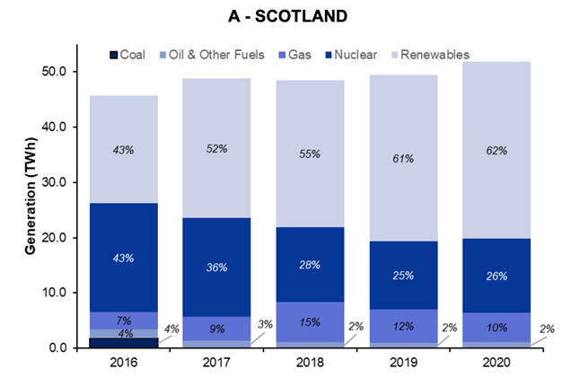

In this Analytics in Business project, we are evaluating rolling out a new program called Heat Smart Orkney (HSO) under this topic. Orkney Isles, an archipelago in the Northern Isles of Scotland, has a lot of wind generation but a limited capacity connector to the mainland. In the situation of high wind, there are power which exceeds the capacity of the connector, so some of the wind energy has to be curtailed and wasted. Now there could potentially exist a situation where we switch on local devices in residents’ homes, such as storage heaters and hot water cylinders, and consume some of this otherwise curtailed wind energy. Therefore, it opens up a potential commercial arrangement where locals get a discount energy rate when the curtailment is ongoing. Also, it provides a business opportunity for us at Kaluza, and local wind farm owners, as well as bringing potentially cheaper electricity to the local population. This report explores the energy curtailment from wind turbines in the Orkney Isles and potentials to reduce it, by analysing data available from a turbine and local demand data.

Reference:

The Equation. 2022. Renewable Energy Curtailment 101: The Problem That’s Actually Not a Problem At All. [online] Available at: https://blog.ucsusa.org/mark-specht/renewable-energy-curtailment-101/ [Accessed 26 May 2022].

## 2 Data Pre-processing

### 2.1 Libraries

The libraries required to conduct analysis have been imported as shown below.

```python
import pandas as pd
import numpy as np
import numpy_financial as npf
import matplotlib.pyplot as plt
from datetime import datetime
from sklearn.model_selection import train_test_split
from sklearn.neighbors import KNeighborsRegressor
from sklearn import metrics
from sklearn.ensemble import RandomForestRegressor
from sklearn.discriminant_analysis import LinearDiscriminantAnalysis
from sklearn.svm import SVR
from sklearn.model_selection import GridSearchCV
```

### 2.2 Datasets

We have had acess to the turbine telemetry dataset which contains telemetry data for a single turbine on the Orkney Isles and a residential demand dataset which contains aggregated residential electrity demand aggregated from thousands of homes in the Orkney Isles.

```python
turbine_data = pd.read_csv('turbine_telemetry.csv', parse_dates=[0], index_col=0)
demand_data = pd.read_csv('residential_demand.csv', parse_dates=[0], index_col=0)
```

The turbine dataset contains four columns as shown below, the Timestamp column has been used as the index to make further analysis easier. Information regarding each column:

**Power_kw** - the measured average power in kw during the measurement period.

**Setpoint_kw** - the average maximum-allowed generator output in kw during the measurement period (set by a controller).

**Wind_ms** - the average wind speed in metres per second during the measurement period.

```python
turbine_data.head()
```

| Timestamp | Power_kw | Setpoint_kw | Wind_ms |
| --- | --- | --- | --- |
| 2015-05-28 00:00:23 | 80.0 | 900.0 | 4.9 |
| 2015-05-28 00:01:23 | 78.0 | 900.0 | 5.4 |
| 2015-05-28 00:02:23 | 52.0 | 900.0 | 4.9 |
| 2015-05-28 00:03:23 | 57.0 | 900.0 | 4.6 |
| 2015-05-28 00:04:23 | 54.0 | 900.0 | 4.6 |

The residential demand dataset contains three columns as shown below, the Timestamp column has again been used as the index to make further analysis easier. Information regarding each column:

**Demand_mean_kw**- the average demand in kw across the households that were sampled.

**N_households** - the count of households sampled to arrive at the mean demand in the previous column.

```python
demand_data.head()
```

| Timestamp | Demand_mean_kw | N_households |
| --- | --- | --- |
| 2017-01-01 00:00:00 | 0.220106 | 5428 |
| 2017-01-01 00:30:00 | 0.205945 | 5429 |
| 2017-01-01 01:00:00 | 0.189090 | 5429 |
| 2017-01-01 01:30:00 | 0.173118 | 5429 |
| 2017-01-01 02:00:00 | 0.159051 | 5429 |

### 2.3 Demand data

Next we check the demand dataset for null values

```python
demand_data.isnull().sum()
```

```
Demand_mean_kw    0
N_households      0
dtype: int64
```

As we can see above, there are no nulls in the demand dataset.

Next we check to see how much of the dataset has a time interval of 30 minutes between measurements.

```python
dt = pd.Series(demand_data.index).diff()
thirty_min = pd.Timedelta(minutes=30)
(dt == thirty_min).sum() / len(dt)
```

```
0.9999430783242259
```

As we can see above, 99.99% of the dataset has a measurement interval of 30 minutes which is perfectly acceptable and the demand dataset is now ready for further analysis.

### 2.4 Turbine data

For the ease of further analysis, the turbine dataset will first be divided into their respective years, 2015, 2016, 2017, 2018.

```python
td_2015 = turbine_data[(turbine_data.index <= datetime(2015, 12, 31))]
td_2016 = turbine_data[(turbine_data.index >= datetime(2016, 1, 1)) & (turbine_data.index <= datetime(2016, 12, 31))]
td_2017 = turbine_data[(turbine_data.index >= datetime(2017, 1, 1)) & (turbine_data.index <= datetime(2017, 12, 31))]
td_2018 = turbine_data[(turbine_data.index >= datetime(2018, 1, 1)) & (turbine_data.index <= datetime(2018, 12, 31))]
```

#### 2.4.1 Turbine data 2015

We will first explore the 2015 turbine telemetry data.

```python
mins_day = 60*24
td_2015.shape[0]/mins_day
```

```
28.202083333333334
```

To get a quick understanding of how much data is available for 2015, we run the above code to dividve the number of rows in the dataframe by the number of minutes in a day, which gives us approximiately how many days of data is available in the dataset. We can see that we have approximately 28 days of data available for 2015 which is insufficient to run meaningful analysis on especially after we look at the below plot which shows huge gaps in the data. There is some days of data around June, some days around September, and some days around December. As the wind speeds will likely vary throughout the year across the different seasons, this data is simply too noisy and very little meaning can be extracted from it.

We therefore conclude that the 2015 turbine telemetry data is not significant enough to warrant further analysis. However, the data will still be used to establish a relationship between wind speed and the turbines power output, this will be discussed further in Section 3.2.

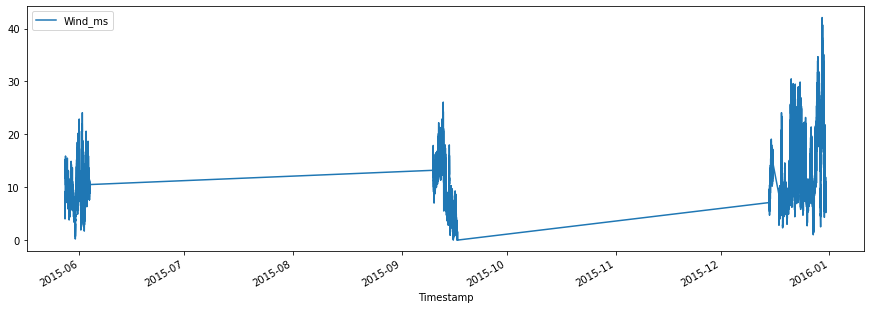

```python
td_2015.plot(y = 'Wind_ms', figsize = (15,5))
```

#### 2.4.2 Turbine data 2016

Next we explore the 2016 turbine telemetry data.

```python
td_2016.shape[0]/mins_day
```

```
357.7784722222222
```

Repeating a similar process as for 2015, we can see that approximately 358 days of data is available for 2016, which is naturally much more significant and certainly worth exploring further. In this initial exploration we can also see that the data is not complete, i.e there should have been 365 days of data but there is clearly less. Looking at the plot below it is hard to determine where the gap is except a small gap is visible around August.

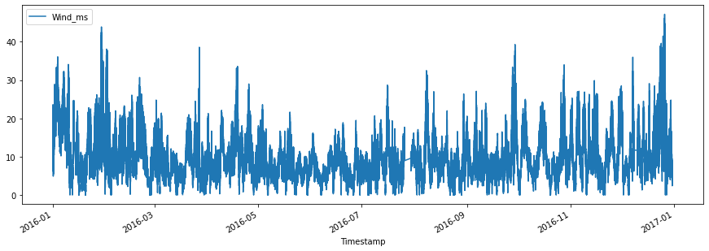

```python
td_2016.plot(y = 'Wind_ms', figsize = (15,5))
```

```python
td_2016.isnull().sum()
```

```
Power_kw       934
Setpoint_kw    943
Wind_ms        936
dtype: int64
```

From the above function we can see that there are several missing values in the 2016 turbine telemetry data, we decide to delete these rows with missing values as they are only a small percentage of the data available.

```python
initial_rows_2016 = td_2016.shape[0] # Number of rows in the dataset with nulls

td_2016 = td_2016.dropna() # Removing the nulls

final_rows_2016 = td_2016.shape[0] # Number of rows in the dataset without nulls

((initial_rows_2016 - final_rows_2016)/initial_rows_2016)*100 # Percentage of rows removed by removing nulls
```

```
0.36432382701120536
```

As we can see from the above piece of analysis, the percentage of the data that was deleted by removing the rows with nulls is only 0.364% which is acceptable. We already know that we have some potential gaps in the data, i.e not all 365 days worth of data is available, and by deleting these null values we have increased that gap, but we will discuss how the gaps are dealt with later in the analysis.

```python
dt = pd.Series(td_2016.index).diff()
one_min = pd.Timedelta(minutes=1)
(dt == one_min).sum() / len(dt)
```

```
0.9857789622148974
```

Along with having gaps, as we can see from the above piece of code, 98.6% of the data has intervals of 1 minute between measurements, which means that there is 1.4% of rows where the timestamp moves by a value other than 1 minute. An elegant method of dealing with this problem will be discussed in Section 4.1.1.

#### 2.4.3 Turbine data 2017

Next we explore the 2017 turbine telemetry data.

```python
td_2017.shape[0]/mins_day
```

```
343.55833333333334
```

Repeating a similar process as for 2015 and 2016, we can see that approximately 343 days of data is available for 2017, which is again significant and certainly worth exploring further. In this initial exploration we can also again see that the data is not complete, i.e there should have been 365 days of data but there is clearly less. Looking at the plot below it is clear that there is a large gap in the data during April. There could be a wide variety of explanations for this missing data, such as the turbine was down for maintenence, measurement equipment failure (i.e it was operating but the data was not collected), turbine was taken offline on purpose.

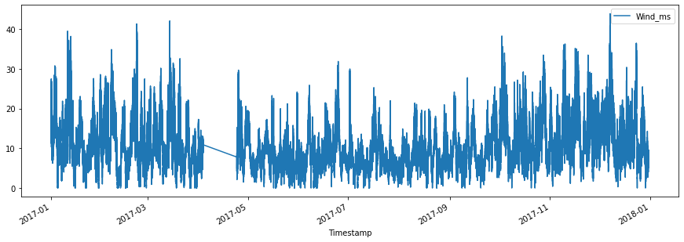

```python
td_2017.plot(y = 'Wind_ms', figsize = (15,5))
```

```python
td_2017.isnull().sum()
```

```
Power_kw       1764
Setpoint_kw    1767
Wind_ms        1765
dtype: int64
```

From the above function we can see that there are several missing values in the 2017 turbine telemetry data, we decide to delete these rows with missing values as they are only a small percentage of the data available.

```python
initial_rows_2017 = td_2017.shape[0] # Number of rows in the dataset with nulls

td_2017 = td_2017.dropna() # Removing the nulls

final_rows_2017 = td_2017.shape[0] # Number of rows in the dataset without nulls

((initial_rows_2017 - final_rows_2017)/initial_rows_2017)*100 # Percentage of rows removed by removing nulls
```

```
0.71373129259951
```

Repeating the above analysis in the same way as for 2016, we can see that 0.71% of the data has been removed, which while not ideal, is still deemed acceptable. Same as for 2016, we are already aware that there is a gap in the 2017 dataset and removing these nulls has created more gaps, the method of dealing with these gaps will be discussed later in the analysis.

```python
dt = pd.Series(td_2017.index).diff()
one_min = pd.Timedelta(minutes=1)
(dt == one_min).sum() / len(dt)
```

```
0.9850405034273697
```

Along with having gaps, as we can see from the above piece of code, 98.5% of the data has intervals of 1 minute between measurements, which means that there is 1.5% of rows where the timestamp moves by a value other than 1 minute. An elegant method of dealing with this problem will be discussed in Section 4.1.1.

#### 2.4.4 Turbine data 2018

Next we explore the 2018 turbine telemetry data.

```python
td_2018.shape[0]/mins_day
```

```
10.247222222222222
```

Repeating the same process as with 2015, 2016, and 2017, we can see that there is only approximiately 10 days worth of data available for 2018. This is certainly too little and not worth exploring any further. However, the data will still be used to establish a relationship between wind speed and the turbines power output, this will be discussed further in Section 3.2.

```python
td_2018.isnull().sum()
```

```
Power_kw       0
Setpoint_kw    0
Wind_ms        0
dtype: int64
```

```python
dt = pd.Series(td_2018.index).diff()
one_min = pd.Timedelta(minutes=1)
(dt == one_min).sum() / len(dt)
```

```
0.9996611547844945
```

There are no null values in the 2018 dataset and the measurements are almost all (99.97%) within a 1 minute interval so no further pre-processing is required.

## 3. Function for Turbine Power Output

### 3.1 Merging processed datasets

Now that we have cleaned the turbine telemetry datasets for the different years we need to merge them back together to do further exploratory data analysis and create a function for the turbines power output given a certain wind speed.

```python
data = [td_2015, td_2016, td_2017, td_2018]
merged = pd.concat(data)
```

### 3.2 Wind vs Power

We can now explore what the relationship between wind speed and power output of the turbine is. We can begin by making a scatter plot with a high transparency alpha parameter (as we are plotting over 1m points).

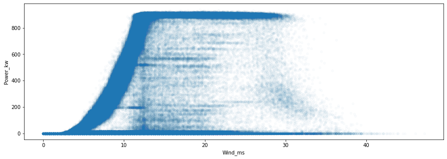

```python
merged.plot.scatter('Wind_ms', 'Power_kw', alpha=0.02, figsize=(15, 5))
```

We can clearly see that at several points in time the turbine is being curtailed, as the power output of the turbine otherwise would fall entirely in the curved shape that is appearing in the data. We now need to remove these curtailed points and other outliers so we can try and create a function for the turbines power output at a given wind speed.

We first calculate the minimum wind speed at which power can be generated using the first line of code shown below. Then we first create a copy of the dataset where the setpoint is at the turbines maximum power output 900, and then locate the rows in which the wind speed is greater than the minimum required for generation but the power output is zero, setting these to zero and then deleting them.

```python
v_min = merged[(merged.loc[:, 'Power_kw'] >= 10.)].loc[:, 'Wind_ms'].quantile(0.10) # Calculating minimum wind speed
merged = merged.query('Setpoint_kw==900').copy() # Taking the rows with setpoint at the maximum output 900kw
merged.loc[((merged.Wind_ms >= v_min) & (merged.Power_kw.abs() <= 1e-5))] = np.nan # Locating rows and replacing with nas
merged = merged.dropna(0, inplace=False) # Deleting the rows which have nas
```

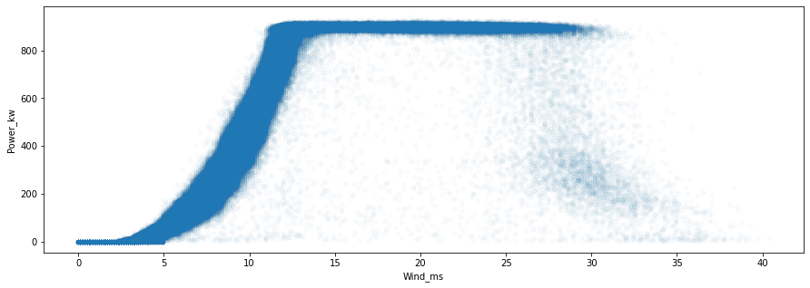

```python
merged.plot.scatter('Wind_ms', 'Power_kw', alpha=0.02, figsize=(15, 5))
```

From the above plot we can see that we have now cleaned the data up significantly and we will now move on to create a function that maps the wind speed to the power output of the turbine.

### 3.3 Fitting models

In this section of the report we will fit the data in different ways and see which model performs best in capturing the relationhip between the wind speed and the power output of the wind turbine.

Before we begin fitting models we first split the available data into a training and test set and use a 80:20 split. This is done as shown below.

```python
np.random.seed(50)
train, test = train_test_split(merged, test_size=0.2)
```

#### 3.3.1 Binning model

As this is a popular technique which has been recommended by stakeholders of this project we will take this as a benchmark model.

We first create the bins with a width of 0.1, in the range 0 to 25 as we take 25m/s as the maximum safe operating speed of the wind turbine.

```python
bins_ = [round(_, 2) for _ in np.arange(0, 25, .1)] # stepsize of 0.1 has been chosen to create a 'smoother' relationship curve
bins = list(zip(bins_, bins_[1:]))
```

```python
def bin_assigner(x, bins=bins):
    for k, (a, b) in enumerate(bins):
        if x >= a and x < b:
            return bins[k]
    else:
        return (24, np.inf)
```

```python
gp_ = train.copy()
gp_['bins'] = gp_.Wind_ms.apply(bin_assigner)
gp_.head()
```

| Timestamp | Power_kw | Setpoint_kw | Wind_ms | bins |
| --- | --- | --- | --- | --- |
| 2016-10-09 05:14:52 | 104.0 | 900.0 | 6.4 | (6.4, 6.5) |
| 2016-04-01 09:03:16 | 906.0 | 900.0 | 15.5 | (15.5, 15.6) |
| 2016-03-03 19:35:37 | 47.0 | 900.0 | 5.6 | (5.6, 5.7) |
| 2017-02-22 16:09:36 | 909.0 | 900.0 | 19.6 | (19.6, 19.7) |
| 2017-08-17 02:03:33 | 403.0 | 900.0 | 9.4 | (9.4, 9.5) |

In the next step we define a get_power function which returns the power output of the turbine for a given wind speed.

```python
gp = gp_[['Power_kw', 'bins']].groupby('bins')
power_med = gp.quantile(0.5)
```

```python
def get_power(ws, df = power_med):
    if ws < 0:
        raise 'Not a valid ws number'
    else:
        bin_idx = bin_assigner(ws)
        return power_med.loc[[bin_idx], 'Power_kw'].values[0]
```

We are now ready to apply the function to the test set, this is done as shown below. To have a consistent scoring mechanism with all the other models we will test, the score is taken as 1 - u/v where u is the residual sum of squares,((y_true - y_pred) **2).sum() and v is the total sum of squares ((y_true - y_true.mean())** 2).sum().

```python
test['Possible_Power'] = test['Wind_ms'].map(lambda x: get_power(x))
```

```python
u = ((test['Power_kw'] - test['Possible_Power']) ** 2).sum()
v = ((test['Power_kw'] - test['Power_kw'].mean())**2).sum()
score = 1 - u/v
score
```

```
0.9679088726022617
```

We obtain a score of 0.9679 (96.79%) on the test set using the benchmark binning technique.

#### 3.3.2 K- Nearest Neighbhours

```python
hyperparameter = {'n_neighbors': [1,50]}
```

```python
np.random.seed(50)
KNN =  KNeighborsRegressor()
KNN = GridSearchCV(KNN, hyperparameter)
```

```python
x_train= train[['Wind_ms']]
y_train = train[['Power_kw']]
x_test = test[['Wind_ms']]
y_test = test[['Power_kw']]
```

```python
KNN.fit(x_train, y_train) # Fitting the KNN model on the training set
```

```
GridSearchCV(estimator=KNeighborsRegressor(),
             param_grid={'n_neighbors': [1, 50]})
```

```python
KNN.score(x_test, y_test) # Scoring the KNN model on the test set
```

```
0.9778271626938686
```

We can see from the above result that the KNN model has a score of 0.9778 (97.78%) which is approximately 1% higher than the benchmark score of the binning technique.

#### 3.3.3 Random Forest

We will now explore if a random forest algorithm can perform better than the benchmark. As there are two hyperparameters the number of trees in the forest, and the max_depth of each tree that need to be chosen, we will run a gridsearch through a range of values and choose via cross validation.

```python
hyperparameters = {'n_estimators': [1,500], 'max_depth': [1,10,100,None]}
```

```python
np.random.seed(50)
RF = RandomForestRegressor()
RF = GridSearchCV(RF, hyperparameters)
```

```python
RF.fit(x_train, train['Power_kw']) # Fitting the Random Forest model on the training set
```

```
GridSearchCV(estimator=RandomForestRegressor(),
             param_grid={'max_depth': [1, 10, 100, None],
                         'n_estimators': [1, 500]})
```

```python
RF.score(x_test, y_test) # Scoring the RF model on the test set
```

```
0.9782033957634751
```

We can see from the above result that the RF model has a score of 0.9782 (97.82%) which is also approximately 1% higher than the benchmark score of the binning technique.

#### 3.3.4 Support Vector Machines

We will now explore if Support Vector Machine (SVM) algorithms can perform better than the benchmark. As there are several hyperparameters, choice of kernel, degree of the polynomial kernel, cost parameter C, error parameter epsilon, we will run a gridsearch through the different hyperparameters and choose via cross validation.

Additionally, as SVMs are extremely computationally expensive given the large amount of data to train over, and they do not significantly benefit from all the extra data, only a random subset of the training data will be used to train the SVMs. The test set remains the same.

```python
hyperparameters = {'kernel':('linear', 'rbf', 'sigmoid', 'poly'), 'degree': [2,3], 'C':[1,10,50,100,500], 'epsilon':[0.01,0.05,0.1,0.3,0.5,0.7]}
```

```python
np.random.seed(50)
SVM = SVR()
SVM = GridSearchCV(SVM, hyperparameters)
train_svm = train.sample(n = 2500)
train_svm_x = train_svm[['Wind_ms']]
```

```python
SVM.fit(train_svm_x, train_svm['Power_kw'][:2500])
```

```
GridSearchCV(estimator=SVR(),
             param_grid={'C': [1, 10, 50, 100, 500], 'degree': [2, 3],
                         'epsilon': [0.01, 0.05, 0.1, 0.3, 0.5, 0.7],
                         'kernel': ('linear', 'rbf', 'sigmoid', 'poly')})
```

```python
SVM.score(x_test, y_test)
```

```
0.9756142078261826
```

We can see from the above result that the SVM model has a score of 0.9756 (97.56%)

### 3.4 Re-train and Predict

Now that we have compared a number of models, we can see that the KNN, RF, and SVM models perform the best and better than the benchmark binnning technique. As KNN is significantly cheaper computationally to retrain as compared to RF and SVM, and the test performances were extremely close, we will retrain the KNN model to the entire dataset and use it to predict the power output of the wind turbine at the given windspeeds in the datasets.

When making our predictions of the power output of the wind turbine, we will now return back to our seperated 2016 and 2017 datasets (explanation for why 2015 and 2018 are not explored was previously given in Section 2.4.1 and 2.4.4) as we want to do further analysis on an annual basis.

```python
hyperparameter = {'n_neighbors': [1,50]}
```

```python
np.random.seed(50)
KNN =  KNeighborsRegressor()
KNN = GridSearchCV(KNN, hyperparameter)
```

```python
x_train= merged[['Wind_ms']]
y_train = merged[['Power_kw']]
```

```python
KNN.fit(x_train, y_train) # Fitting the KNN model on the entire dataset
```

```
GridSearchCV(estimator=KNeighborsRegressor(),
             param_grid={'n_neighbors': [1, 50]})
```

```python
td_2016_wind = td_2016[['Wind_ms']]
td_2016_pred = KNN.predict(td_2016_wind)
td_2017_wind = td_2017[['Wind_ms']]
td_2017_pred = KNN.predict(td_2017_wind)
```

```python
td_2016['Possible_Power'] = td_2016_pred
td_2017['Possible_Power'] = td_2017_pred
```

```python
td_2016.head()
```

| Timestamp | Power_kw | Setpoint_kw | Wind_ms | Possible_Power |
| --- | --- | --- | --- | --- |
| 2016-01-01 00:00:34 | 904.0 | 900.0 | 17.0 | 900.50 |
| 2016-01-01 00:01:34 | 899.0 | 900.0 | 15.1 | 900.54 |
| 2016-01-01 00:02:34 | 911.0 | 900.0 | 18.1 | 899.38 |
| 2016-01-01 00:03:34 | 900.0 | 900.0 | 23.1 | 899.90 |
| 2016-01-01 00:04:34 | 903.0 | 900.0 | 19.4 | 900.14 |

```python
td_2017.head()
```

| Timestamp | Power_kw | Setpoint_kw | Wind_ms | Possible_Power |
| --- | --- | --- | --- | --- |
| 2017-01-01 00:00:20 | 900.0 | 900.0 | 13.1 | 878.82 |
| 2017-01-01 00:01:20 | 756.0 | 900.0 | 12.4 | 867.28 |
| 2017-01-01 00:02:20 | 907.0 | 900.0 | 13.8 | 899.78 |
| 2017-01-01 00:03:20 | 906.0 | 900.0 | 13.3 | 898.90 |
| 2017-01-01 00:04:20 | 860.0 | 900.0 | 12.9 | 896.64 |

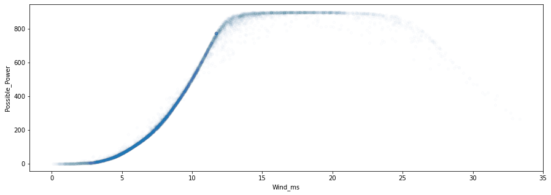

```python
td_2016.plot.scatter('Wind_ms', 'Possible_Power', alpha=0.01, figsize=(15, 5))
```

From the above scatter plot we can clearly see that the KNN model has captured the relationship between wind speed and power output of the turbine extremely well.

Now that we have our predicted possible power output of the turbine for both years as shown in the above dataframes, we can now move further with the analysis to calculate the annual energy curtailment in 2016 and 2017.

## 4. Annual Energy Curtailment

### 4.1 Curtailment in 2016

In this section we will now calculate the energy curtailment in 2016 and look further into the curtailment data.

#### 4.1.1 Solution for the Dirty Data

We can deal with the problem that the data for 2016 is not all in 1 minute intervals by adopting the following technique. We group the data by the month, followed by the day, followed by the hour. By doing so we have now reduced the number of rows in our dataset significantly and most importantly now can deal with the dirty data.

Why group/aggregate to an hour? The reasoning behind grouping the data into hourly slots is that from a practical business perspective, the end goal of this project is to turn on and off quantum heaters in Kaluzas customers homes, and it is simply not practical to do so on a minute by minute basis, instead predicting 1 hour ahead what the wind speed will be during the hour, we can either decide to turn on or off the charging of the quantum heaters in our customers homes.

The way in which this also deals with the dirty data is that for example we can see below that on 1st of January 2016 at 1am there is a count of 60, which means that there are all 60 readings available for within that hour, and we will now be averaging the grouped dataframe (taking the mean of Power_kw, Setpoint_kw, Wind_ms, and Possible_Power) according to the number of measurement readings available in each respective hour.

All data from 2016 were included when calculating the energy curtailment. Even though there is no curtailment occurs when the setpoint is at 900kw, the model used for predicting the maximum possible power has an accuracy of 97.78%. With a high accuracy, the difference between the actual power generated and the possible power will be small compared to the total curtailed energy for hours with a 900kw setpoint.

```python
td_2016 = td_2016.groupby([td_2016.index.month, td_2016.index.day, td_2016.index.hour])
```

```python
td_2016.describe()
```

[output not shown]

```python
td_2016 = td_2016.mean()
```

```python
td_2016.head()
```

[output not shown]

As we can see from the table above, we have now averaged the dataframe to each hour in the year. However, an important note here is that we can see that the dataframe only has 8618 rows, and there should be 8760 (24 hours * 365 days) rows in the complete dataset. We still do have the gaps in the dataset which we will shortly address how we deal with.

#### 4.1.2 Calculating Curtailment

We now calculate the curtailed power for each hour in 2016 by subtracting the uncurtailed power, Possible_Power from the actual generated power, Power_kw. We only want the positive values, because when the Curtailed_Power is negative or zero, it means energy is not being curtailed.

```python
td_2016['Curtailed_Power'] = td_2016['Possible_Power'] - td_2016['Power_kw']
td_2016['Curtailed_Power'] = td_2016[td_2016.Curtailed_Power > 0]['Curtailed_Power']
```

```python
td_2016.head()
```

| Timestamp | Timestamp | Timestamp | Power_kw | Setpoint_kw | Wind_ms | Possible_Power | Curtailed_Power |
| --- | --- | --- | --- | --- | --- | --- | --- |
| 1 | 1 | 0 | 831.283333 | 900.0 | 13.868333 | 833.074000 | 1.790667 |
|  |  | 1 | 896.766667 | 900.0 | 16.463333 | 896.399667 | NaN |
|  |  | 2 | 841.250000 | 900.0 | 12.855000 | 831.113333 | NaN |
|  |  | 3 | 652.816667 | 900.0 | 11.286667 | 681.222333 | 28.405667 |
|  |  | 4 | 334.433333 | 900.0 | 8.725000 | 342.958667 | 8.525333 |

As we can see in the above table, the curtialed power has now been calculated correctly and we can now calculate the total energy curtailed for 1 turbine in 2016.

#### 4.1.3 Energy Curtailed for 1 Turbine in 2016

The curtailed power in each row of the dataframe is automatically the curtailed energy in kwh for that hour because the data is grouped by hours (for eg. 1.79kw on 1st January 2016 at 12am is equvalent to 1.79kwh of energy consumed in the hour from 12am to 1am).

We can therefore calculate the total energy curtailed for 1 turbine in 2016 by doing a simple summation of the Curtailed_Power column. However, we now need to account for the fact that the data has gaps in it and we are only summing over 8618 rows rather than 8760 rows. The way we deal with this is to assume that the missing Curtailed_Power values take the value of the average of the Curtailed_Power across 2016. This is a reasonable approximation because we are unaware of the real reasons behind the missing data, and so the average of the rest of the data is the best guess we can make for the missing data.

As we assume the missing data takes on the same value as the average of the available data, the total curtailed energy for 1 turbine in 2016 is then calculated by multiplying the sum of the column by a factor of 8760/8618.

```python
Curtailed_Energy_2016_1 = (td_2016.Curtailed_Power).sum() * (8760/8618)
Curtailed_Energy_2016_1
```

```
900052.9176029849
```

Therefore, the total energy curtailed for 1 turbine in 2016 is 900,052 kwh. We can now calculate the total energy curtailed across all the wind turbines in the Orkney Isles in 2016.

#### 4.1.4 Total Energy Curtailed in 2016

There are over 500+ wind turbines installed in the Orkney Isles, for the purpose of this report we will assume that the number of wind turbines is exactly 500.

It is important to appreciate the fact that not all turbines will be of the same size, shape, location, efficiency, facing the same wind direction as the single turbine for which we have the data available for. It is naturally difficult to account for all these different factors and more in a scientific/accurate way, but for the purposes of this report, a simplification will be made which is simply discounting the total energy from all 500 wind turbines by a factor of 20% to account for these differences.

Furthermore, it is also important to appreciate that the turbines do not have 100% uptime and will be down for maintenance and repairs. Based on a survey report by S.Sheng published in 2013 by the National Renewable Energy Laborotory (NREL) (reference below), which contained data for over 1500 wind turbines, a reasonable estimate of the downtime of each turbine can be taken to be approximately 14 days in a year. Therefore, we also discount the total energy by a factor of 351/365 to account for this.

*REF - Sheng, S., 2013. Report on Wind Turbine Subsystem Reliability - A Survey of Various Databases (Presentation) NREL (National Renewable Energy Laboratory).

Therefore, the **total energy curtailed in 2016** across the 500 turbines in the Orkney Isles is **346,212,135 kwh**.

```python
Curtailed_Energy_2016_Total = Curtailed_Energy_2016_1 * 500 * 0.8 * (351/365)
Curtailed_Energy_2016_Total
```

```
346212135.9766002
```

### 4.2 Curtailment in 2017

In this section we will now calculate the energy curtailment in 2017 and look further into the curtailment data.

#### 4.2.1 Solution for the Dirty Data

The dirty data is dealt with in the same way as with the 2016 data. Please refer to Section 4.1.1 for further details.

```python
td_2017 = td_2017.groupby([td_2017.index.month, td_2017.index.day, td_2017.index.hour])
```

```python
td_2017.describe()
```

| Timestamp | Timestamp | Timestamp | Power_kw count | Power_kw mean | Power_kw std | Power_kw min | Power_kw 25% | Power_kw 50% | Power_kw 75% | Power_kw max | Setpoint_kw count | Setpoint_kw mean | ... | Wind_ms 75% | Wind_ms max | Possible_Power count | Possible_Power mean | Possible_Power std | Possible_Power min | Possible_Power 25% | Possible_Power 50% | Possible_Power 75% | Possible_Power max |
| --- | --- | --- | --- | --- | --- | --- | --- | --- | --- | --- | --- | --- | --- | --- | --- | --- | --- | --- | --- | --- | --- | --- | --- |
| 1 | 1 | 0 | 60.0 | 896.150000 | 32.556509 | 710.0 | 898.75 | 904.0 | 907.25 | 922.0 | 60.0 | 900.0 | ... | 16.625 | 19.2 | 60.0 | 892.812000 | 20.821340 | 751.66 | 894.520 | 899.35 | 900.700 | 901.60 |
|  |  | 1 | 60.0 | 905.350000 | 9.040071 | 850.0 | 903.00 | 906.0 | 910.00 | 919.0 | 60.0 | 900.0 | ... | 18.450 | 21.6 | 60.0 | 897.875667 | 11.818653 | 810.72 | 899.260 | 899.96 | 900.765 | 901.88 |
|  |  | 2 | 47.0 | 906.170213 | 3.919401 | 898.0 | 904.00 | 905.0 | 908.50 | 918.0 | 47.0 | 900.0 | ... | 18.950 | 20.7 | 47.0 | 899.223830 | 3.858843 | 883.62 | 899.280 | 900.18 | 900.820 | 901.74 |
|  |  | 3 | 73.0 | 904.109589 | 19.817614 | 743.0 | 903.00 | 906.0 | 910.00 | 920.0 | 73.0 | 900.0 | ... | 19.500 | 27.5 | 73.0 | 894.332603 | 18.116917 | 790.10 | 898.860 | 900.18 | 901.000 | 902.30 |
|  |  | 4 | 60.0 | 904.316667 | 10.833864 | 830.0 | 902.75 | 905.0 | 909.00 | 916.0 | 60.0 | 900.0 | ... | 17.700 | 20.9 | 60.0 | 897.315333 | 17.410900 | 766.74 | 899.640 | 900.19 | 900.760 | 901.60 |
| ... | ... | ... | ... | ... | ... | ... | ... | ... | ... | ... | ... | ... | ... | ... | ... | ... | ... | ... | ... | ... | ... | ... | ... |
| 12 | 30 | 19 | 60.0 | 208.250000 | 28.412593 | 126.0 | 190.75 | 209.0 | 228.50 | 272.0 | 60.0 | 900.0 | ... | 7.800 | 8.4 | 60.0 | 210.574333 | 36.294472 | 112.38 | 185.620 | 206.88 | 225.560 | 297.72 |
|  |  | 20 | 60.0 | 121.100000 | 45.483728 | 31.0 | 97.00 | 122.0 | 147.00 | 247.0 | 60.0 | 900.0 | ... | 6.900 | 7.8 | 60.0 | 128.217667 | 47.816190 | 22.56 | 101.280 | 133.86 | 164.120 | 225.56 |
|  |  | 21 | 60.0 | 177.166667 | 47.391327 | 72.0 | 152.75 | 184.5 | 211.00 | 275.0 | 60.0 | 900.0 | ... | 7.800 | 8.5 | 60.0 | 198.118667 | 54.519531 | 60.70 | 161.830 | 206.88 | 225.560 | 305.66 |
|  |  | 22 | 60.0 | 184.550000 | 31.961537 | 129.0 | 168.50 | 184.0 | 207.00 | 258.0 | 60.0 | 900.0 | ... | 7.700 | 9.0 | 60.0 | 201.400667 | 45.201558 | 97.00 | 183.240 | 206.68 | 216.560 | 371.02 |
|  |  | 23 | 60.0 | 221.850000 | 111.508581 | 74.0 | 125.50 | 194.0 | 314.00 | 464.0 | 60.0 | 900.0 | ... | 8.425 | 9.6 | 60.0 | 228.744667 | 103.152209 | 101.28 | 149.265 | 196.15 | 299.705 | 433.48 |

8234 rows × 32 columns

```python
td_2017 = td_2017.mean()
```

Once again as we can see from the table above, there are 8234 rows instead of 8760 rows, i.e there are gaps in the data as we have previously explored in Section 2.4.3. The missing data will be dealt with in Section 4.2.3.

#### 4.2.2 Calculating Curtailment

The curtailment is calculated in the same way as with the 2016 data. Please refer to Section 4.1.2 for further details.

```python
td_2017['Curtailed_Power'] = td_2017['Possible_Power'] - td_2017['Power_kw']
td_2017['Curtailed_Power'] = td_2017[td_2017.Curtailed_Power > 0]['Curtailed_Power']
```

#### 4.2.3 Energy Curtailed for 1 turbine in 2017

The energy curtailed for 1 turbine in 2017 is calculated the same way as with the 2016 data. The gap in the data/missing data is also dealt with in the same way as the 2016 data. Please refer to section 4.1.3 for further details.

```python
Curtailed_Energy_2017_1 = (td_2017.Curtailed_Power).sum() * (8760/8234)
Curtailed_Energy_2017_1
```

```
473891.6865285564
```

Therefore, the total energy curtailed for 1 turbine in 2017 is 473,891 kwh. We can now calculate the total energy curtailed across all the wind turbines in the Orkney Isles in 2017.

#### 4.2.4 Total Energy Curtailed in 2017

The total energy curtailed in 2017 is calculated in the samw way as with 2016 data. Please refer to section 4.1.4 for further details.

```python
Curtailed_Energy_2017_Total = Curtailed_Energy_2017_1 * 500 * 0.8* (351/365)
Curtailed_Energy_2017_Total
```

```
182286007.64002556
```

Therefore, the **total energy curtailed in 2017** across the 500 turbines in the Orkney Isles is **182,286,007 kwh**.

### 4.3 Understanding the Curtailment

#### 4.3.1 Curtailment in Percentage Terms

To better understand the energy being curtailed, we can calculate what it means in terms of the energy being generated by the turbine and the theoretical maximum energy generation. The theoretical maximum energy generated by a turbine is if it was operating at maximum capacity, 900kw, for 24 hours a day, 365 days a year. The theoretical maximum, while has no practical implications, is a good way to sense check the numbers obtained.

```python
Theoretical_maximum = 900*24*365
(Curtailed_Energy_2016_1/Theoretical_maximum) * 100
```

```
11.416196316628424
```

```python
(Curtailed_Energy_2016_1/((td_2016.Power_kw.sum()*(8760/8618)))) * 100
```

```
32.90685613379177
```

```python
(Curtailed_Energy_2017_1/Theoretical_maximum) * 100
```

```
6.010802721062359
```

```python
(Curtailed_Energy_2017_1/((td_2017.Power_kw.sum()*(8760/8234)))) * 100
```

```
13.12637619791335
```

#### 4.3.2 2016 vs 2017

We can observe that there is a very large difference in the energy curtailment in 2016 vs 2017, 346m kwh and 182m kwh respectively. To investigate this difference, we can first check if the wind speed profiles in 2016 and 2017 were significantly different to cause a near 2x difference in curtailed energy.

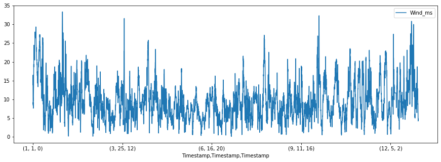

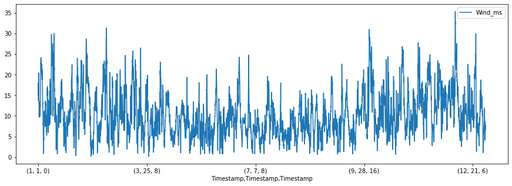

```python
td_2016.plot(y = 'Wind_ms', figsize = (15,5))
td_2017.plot(y = 'Wind_ms', figsize = (15,5))
```

There are no signs of significant differences in the wind profile, so while some randomness in the wind speed can account for a small variation in the curtailments for 2016 and 2017, the wind profile certainly cannot explain a near 2x difference in curtailment.

#### 4.3.3 Curtailment Spread

While it is important to understand curtailment in the aggregated form for a year, we also need to dig deeper and see how the curtailment is dsitributed throughout the year. We begin by plotting the curtailment as a timeseries for both years.

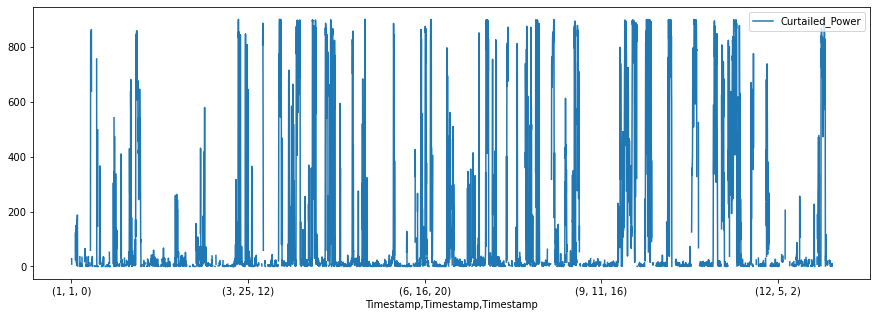

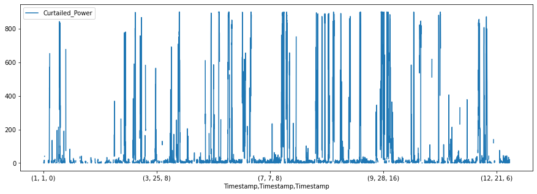

```python
td_2016.plot(y = 'Curtailed_Power', figsize = (15,5))
td_2017.plot(y = 'Curtailed_Power', figsize = (15,5))
```

From first glance it is apparent that the energy curtailed in 2016 is significantly greater than that in 2017, which follows from our analysis in Section 4.3.2. What we can also observe is that there are clearly significant spikes in energy curtailment (peaks touching 900kw), to the point where the turbine could have been operating at 900kw but has been switched off.

At the same time there are several days where the curtailment is close to zero, something that we will explore in greater detail in section 5.2.8 of the report, as we need to identify those weak points that could significantly affect our financial modelling when there isn't enough energy being curtailed.

## 5. Curtailment Control via Demand Response

### 5.1 Total Demand

As per National Records of Scotland there are approximiately 10,000 households in the Orkney Isles, and for all further analysis we will assume this number of 10,000 households to be reasonbly accurate.

As we have the mean demand in kw measured at half hour intervals in our demand dataset, we can calculate the total demand in kw at every half hour interval by simply multiplying the mean demand by 10,000.

The demand that we are interested in is the energy that is consumed for heating these homes. It is common knowledge that the majority of energy consumed by homes goes towards heating, and therefore, we shall assume that 80% of the energy demand is for heating purposes. Hence, we will also discount the total demand by a factor of 0.8 to account for the fact that not all of the demand goes towards heating the homes.

```python
demand_data['Total_demand_kw'] = demand_data['Demand_mean_kw'] * 10000  * 0.8
demand_data.head()
```

| Timestamp | Demand_mean_kw | N_households | Total_demand_kw |
| --- | --- | --- | --- |
| 2017-01-01 00:00:00 | 0.220106 | 5428 | 1760.851879 |
| 2017-01-01 00:30:00 | 0.205945 | 5429 | 1647.560877 |
| 2017-01-01 01:00:00 | 0.189090 | 5429 | 1512.719101 |
| 2017-01-01 01:30:00 | 0.173118 | 5429 | 1384.944557 |
| 2017-01-01 02:00:00 | 0.159051 | 5429 | 1272.405231 |

Now that we have the total demand in kw over every half hour interval we can aggregate the data into hourly intervals for the same reasons as we aggregated the turbine telemetry data which is that from a practical business perspective we will not be turning on and off charging heaters in customers homes at half hour intervals, it is much more practical to be doing it on an hourly basis.

```python
demand_data_hour = demand_data.groupby([demand_data.index.month, demand_data.index.day, demand_data.index.hour])
demand_data_hour = demand_data_hour.mean()
```

```python
demand_data_hour.head()
```

| Timestamp | Timestamp | Timestamp | Demand_mean_kw | N_households | Total_demand_kw |
| --- | --- | --- | --- | --- | --- |
| 1 | 1 | 0 | 0.216327 | 8079.75 | 1730.613486 |
|  |  | 1 | 0.186112 | 8080.00 | 1488.896019 |
|  |  | 2 | 0.158829 | 8079.50 | 1270.630057 |
|  |  | 3 | 0.139556 | 8079.50 | 1116.447885 |
|  |  | 4 | 0.127389 | 8080.00 | 1019.113996 |

Now we can calculate what the total energy demand in kwh across the entire year of 2017 would be by doing a sum of the total_demand_kw column as the power is measured on a per hour basis in our aggregation, and therefore naturally converts into energy units by multiplying by 1. As we can see below the **total energy demand for 2017 is 15,344,358 kwh**.

```python
Energy_Demand = (demand_data_hour.Total_demand_kw).sum()
Energy_Demand
```

```
15344358.671269385
```

### 5.2 Curtailment vs Demand

#### 5.2.1 The Big Picture

Now that we understand what the total energy demand on the Orkney Isles is, we can compare it to the total energy curtailed in the years 2016 and 2017. It is extremely important to note that these aggregate calculations can only provide us a high level understanding of the amount of curtailed energy versus the demand, as we are aware that curtailed energy is not spread evenly or in the same distribution as the demand is. Therefore, to get a deeper understanding of how much energy curtailment can be avoided via demand response, we need to dig deeper into the data and this will be done in further into the report.

```python
Curtailed_Energy_2016_Total/Energy_Demand
```

```
22.562828684710304
```

```python
Curtailed_Energy_2017_Total/Energy_Demand
```

```
11.879675882533684
```

At a high level aggregation, the total energy curtailed in 2016 is approximately 22 times higher than the energy demand, and the total energy curtailed in 2017 is approximately 12 times higher than the energy demand. This result goes to show how large the energy curtailment currently is, as the energy that is being curtailed in 2017 is enough to power the 10,000 homes, 12 times over. It is clearly visible from the analysis thus far that we may only be able to put a small dent in the curtailment via demand response as the energy available far outstrips the demand from the 10,000 homes in the Orkney Isles.

#### 5.2.2 Shifting the Demand

Next we shall explore how we can shift the demand for energy to non-peak periods (which will also be the periods where there is curtailed energy available). The way to achieve this is by installing quantum heaters, which can be charged to store energy that can be released later when it is required. First we will calculate the total demand for each day as this will give us an understanding of the energy capacity required of out quantum heaters.

```python
demand_data_day = demand_data.groupby([demand_data.index.month, demand_data.index.day])
demand_data_day = demand_data_day.mean()
```

```python
demand_data_day['Daily_Demand_kwh'] = demand_data_day['Demand_mean_kw'] * 24 * 0.8
demand_data_day.head()
```

| Timestamp | Timestamp | Demand_mean_kw | N_households | Total_demand_kw | Daily_Demand_kwh |
| --- | --- | --- | --- | --- | --- |
| 1 | 1 | 0.268558 | 8080.010417 | 2148.463168 | 5.156312 |
|  | 2 | 0.274165 | 5430.604167 | 2193.316005 | 5.263958 |
|  | 3 | 0.273080 | 5423.437500 | 2184.639982 | 5.243136 |
|  | 4 | 0.264684 | 5443.208333 | 2117.474039 | 5.081938 |
|  | 5 | 0.268231 | 5473.375000 | 2145.846754 | 5.150032 |

```python
maximum_daily_demand = (demand_data_day.Daily_Demand_kwh).max()
maximum_daily_demand
```

```
5.708525127986938
```

Now that we know the maximum average daily demand for 1 household across any day in the year 2017 is 5.71 kwh, we can pick an appopriate quantum heater to work with for further analysis. We will be chosing the Quantum Heater by Dimplex with an input rating of 1.1kw, storage capacity of 7.7kwh and heat ouput rate of 0.5kw (https://www.dimplex.co.uk/product/quantum-heater).

#### 5.2.3 Visualising Demand

Now that we have picked a quantum heater we need to visualise the demand patterns throughout the day to understand when the devices need to be charged. We shall visualise the daily demand aggregated to a monthly level as plotting 365 graphs will reveal no meaningful insights but plotting 12 months we can see how the daily demand varies across the year. We will use the function shown below to calculate the average demand per hour in a specified month.

```python
def get_hour_average(month, data):
    data.fillna(0, inplace = True)

    curtail_per_hour = []
    hour_list = [0, 1, 2, 3, 4, 5, 6, 7, 8, 9, 10 ,11, 12, 13, 14, 15, 16, 17, 18, 19, 20, 21, 22, 23]
    answer_list = [[] for _ in range(24)]

    for i in range(len(data.index)):
        for j in hour_list:
            if data.index[i][0] == month and data.index[i][2] == j:
                answer_list[j].append(data[data.index[i]])

    for item in answer_list:
        curtail_per_hour.append(sum(item)/len(item))
    return curtail_per_hour

jan = get_hour_average(1,demand_data_hour['Demand_mean_kw'])
feb = get_hour_average(2,demand_data_hour['Demand_mean_kw'])
mar = get_hour_average(3,demand_data_hour['Demand_mean_kw'])
apr = get_hour_average(4,demand_data_hour['Demand_mean_kw'])
may = get_hour_average(5,demand_data_hour['Demand_mean_kw'])
jun = get_hour_average(6,demand_data_hour['Demand_mean_kw'])
jul = get_hour_average(7,demand_data_hour['Demand_mean_kw'])
aug = get_hour_average(8,demand_data_hour['Demand_mean_kw'])
sep = get_hour_average(9,demand_data_hour['Demand_mean_kw'])
octo = get_hour_average(10,demand_data_hour['Demand_mean_kw'])
nov = get_hour_average(11,demand_data_hour['Demand_mean_kw'])
dec = get_hour_average(12,demand_data_hour['Demand_mean_kw'])
```

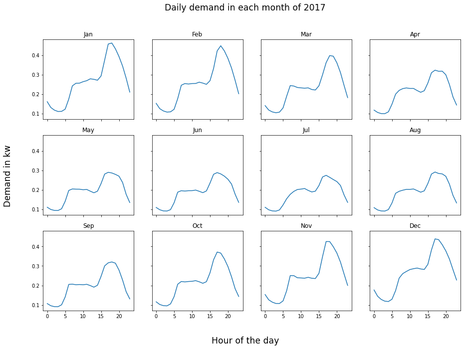

```python
fig, axs = plt.subplots(3,4, sharex = True, sharey = True, figsize = (15,10))
fig.suptitle('Daily demand in each month of 2017', fontsize = 'xx-large')
fig.text(0.5, 0.04, 'Hour of the day', ha='center', va='center', fontsize = 'xx-large')
fig.text(0.06, 0.5, 'Demand in kw', ha='center', va='center', rotation='vertical', fontsize = 'xx-large')
axs[0,0].plot(jan)
axs[0,0].set_title('Jan')
axs[0,1].plot(feb)
axs[0,1].set_title('Feb')
axs[0,2].plot(mar)
axs[0,2].set_title('Mar')
axs[0,3].plot(apr)
axs[0,3].set_title('Apr')
axs[1,0].plot(may)
axs[1,0].set_title('May')
axs[1,1].plot(jun)
axs[1,1].set_title('Jun')
axs[1,2].plot(jul)
axs[1,2].set_title('Jul')
axs[1,3].plot(aug)
axs[1,3].set_title('Aug')
axs[2,0].plot(sep)
axs[2,0].set_title('Sep')
axs[2,1].plot(octo)
axs[2,1].set_title('Oct')
axs[2,2].plot(nov)
axs[2,2].set_title('Nov')
axs[2,3].plot(dec)
axs[2,3].set_title('Dec')
```

From the above plots we can clearly see that there is a common trend to how energy is being consumed, with a morning peak around 6am and an evening peak around 5pm. The peaks are even larger in the winter months which makes intuitive sense as in the colder months more energy is being consumed to heat homes as compared to summer months. Now that we have seen what the demand profile looks like, if we want to shift the peak and charge up quantum heaters in the off-peak time, we have two intervals available, between midnight to 4am and around 9am to 4pm.

#### 5.2.4 Quantum Heater

Given our quantum heater charges at a rate of 1.1kw, and we can see the average daily demand shown below is 4.2 kwh, we need approximately 3-5 hours of charging time depending on the time of the year (need more energy in winter years so longer charging time and vice versa for the summer). That means that in the midnight to 4am interval and 9am to 4pm interval, in those 4 + 7 = 11 hour intervals we need approximately 3-5 hours where the curtailed power would be sufficient to charge the quantum heaters.

```python
(demand_data_day.Daily_Demand_kwh).mean()
```

```
4.203933882539559
```

#### 5.2.5 Curtailment Requirement Methodology

To correctly calculate the curtailed power required we will take the following approach. We wish to establish a minimum curtailed power number that will ensure that our customers will have the energy available to charge their quantum heaters 365 days a year. To that end, the worst-case/maximum power requirement will be calculated, as by intuitive logic, if there is enough curtailed power to meet the worst case power requreiment, there will definitely be sufficient curtailed power to meet the demand requirement at any other moment in time. Furthermore, as we are planning for the worst case, we will assume the 2017 curtailment model to be a typical one rather than the 2016 model where we have significantly larger amount of curtailment. The thought process behind selecting 2017 as the data for further analysis is the same intuitive logic, which is that if the financial model works with lower energy curtailment as in 2017, it will automatically also work (will work even better) for 2016 type data.

#### 5.2.6 Demand Response Scenarios

All further analysis will now be carried out taking three different demand response scenarios: Scenario 25 - This is the scenario in which 25% of the homes in the Orkney Isles will take on our product Scenario 50 - This is the scenario in which 50% of the homes in the Orkney Isles will take on our product Scenario 75 - This is the scenario in which 75% of the homes in the Orkney Isles will take on our product

#### 5.2.7 Curtailment Requirement Scenarios

Now we shall calculate the required curtailment power to meet the demand from 25% of homes in the Ornkey Isles.

As each home will have a quantum heater with an input rating of 1.1kw and there are 2,500 homes, the total power requirement is 2750kw. Each turbine will have to provide 2750/500 = 5.5kw of curtailed power in order to satisfy the demand. As we want to assume the worst case which will be the winter period, where we will have to charge the quantum heaters for 5 hours, we need to ensure that there is a 5 hour timeslot within the off-peak periods with a minimum power of 5.5kw.

Repeating the above process for 50% scenario we get a minimum power requirement of 11kw.

Repeating the above process for 75% scenario we get a minimum power requirement of 16.5kw.

```python
jan = get_hour_average(1,td_2017['Curtailed_Power'])
feb = get_hour_average(2,td_2017['Curtailed_Power'])
mar = get_hour_average(3,td_2017['Curtailed_Power'])
apr = get_hour_average(4,td_2017['Curtailed_Power'])
may = get_hour_average(5,td_2017['Curtailed_Power'])
jun = get_hour_average(6,td_2017['Curtailed_Power'])
jul = get_hour_average(7,td_2017['Curtailed_Power'])
aug = get_hour_average(8,td_2017['Curtailed_Power'])
sep = get_hour_average(9,td_2017['Curtailed_Power'])
octo = get_hour_average(10,td_2017['Curtailed_Power'])
nov = get_hour_average(11,td_2017['Curtailed_Power'])
dec = get_hour_average(12,td_2017['Curtailed_Power'])
```

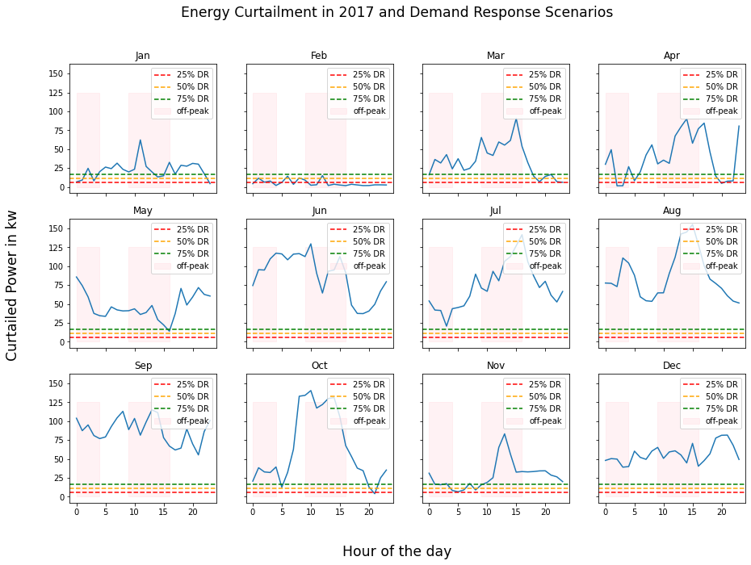

```python
fig, axs = plt.subplots(3,4, sharex = True, sharey = True, figsize = (15,10))
fig.suptitle('Energy Curtailment in 2017 and Demand Response Scenarios', fontsize = 'xx-large')
fig.text(0.5, 0.04, 'Hour of the day', ha='center', va='center', fontsize = 'xx-large')
fig.text(0.06, 0.5, 'Curtailed Power in kw', ha='center', va='center', rotation='vertical', fontsize = 'xx-large')
axs[0,0].plot(jan)
axs[0,0].set_title('Jan')
axs[0,1].plot(feb)
axs[0,1].set_title('Feb')
axs[0,2].plot(mar)
axs[0,2].set_title('Mar')
axs[0,3].plot(apr)
axs[0,3].set_title('Apr')
axs[1,0].plot(may)
axs[1,0].set_title('May')
axs[1,1].plot(jun)
axs[1,1].set_title('Jun')
axs[1,2].plot(jul)
axs[1,2].set_title('Jul')
axs[1,3].plot(aug)
axs[1,3].set_title('Aug')
axs[2,0].plot(sep)
axs[2,0].set_title('Sep')
axs[2,1].plot(octo)
axs[2,1].set_title('Oct')
axs[2,2].plot(nov)
axs[2,2].set_title('Nov')
axs[2,3].plot(dec)
axs[2,3].set_title('Dec')
label = '5.5kw'
axs[0,0].axhline(y = 5.5, c = 'red',ls ='--', label = '25% DR')
axs[0,1].axhline(y = 5.5, c = 'red',ls ='--', label = '25% DR')
axs[0,2].axhline(y = 5.5, c = 'red',ls ='--', label = '25% DR')
axs[0,3].axhline(y = 5.5, c = 'red',ls ='--', label = '25% DR')
axs[1,0].axhline(y = 5.5, c = 'red',ls ='--', label = '25% DR')
axs[1,1].axhline(y = 5.5, c = 'red',ls ='--', label = '25% DR')
axs[1,2].axhline(y = 5.5, c = 'red',ls ='--', label = '25% DR')
axs[1,3].axhline(y = 5.5, c = 'red',ls ='--', label = '25% DR')
axs[2,0].axhline(y = 5.5, c = 'red',ls ='--', label = '25% DR')
axs[2,1].axhline(y = 5.5, c = 'red',ls ='--', label = '25% DR')
axs[2,2].axhline(y = 5.5, c = 'red',ls ='--', label = '25% DR')
axs[2,3].axhline(y = 5.5, c = 'red',ls ='--', label = '25% DR')

axs[0,0].axhline(y = 11, c = 'orange',ls ='--', label = '50% DR')
axs[0,1].axhline(y = 11, c = 'orange',ls ='--', label = '50% DR')
axs[0,2].axhline(y = 11, c = 'orange',ls ='--', label = '50% DR')
axs[0,3].axhline(y = 11, c = 'orange',ls ='--', label = '50% DR')
axs[1,0].axhline(y = 11, c = 'orange',ls ='--', label = '50% DR')
axs[1,1].axhline(y = 11, c = 'orange',ls ='--', label = '50% DR')
axs[1,2].axhline(y = 11, c = 'orange',ls ='--', label = '50% DR')
axs[1,3].axhline(y = 11, c = 'orange',ls ='--', label = '50% DR')
axs[2,0].axhline(y = 11, c = 'orange',ls ='--', label = '50% DR')
axs[2,1].axhline(y = 11, c = 'orange',ls ='--', label = '50% DR')
axs[2,2].axhline(y = 11, c = 'orange',ls ='--', label = '50% DR')
axs[2,3].axhline(y = 11, c = 'orange',ls ='--', label = '50% DR')

axs[0,0].axhline(y = 16.5, c = 'green',ls ='--', label = '75% DR')
axs[0,1].axhline(y = 16.5, c = 'green',ls ='--', label = '75% DR')
axs[0,2].axhline(y = 16.5, c = 'green',ls ='--', label = '75% DR')
axs[0,3].axhline(y = 16.5, c = 'green',ls ='--', label = '75% DR')
axs[1,0].axhline(y = 16.5, c = 'green',ls ='--', label = '75% DR')
axs[1,1].axhline(y = 16.5, c = 'green',ls ='--', label = '75% DR')
axs[1,2].axhline(y = 16.5, c = 'green',ls ='--', label = '75% DR')
axs[1,3].axhline(y = 16.5, c = 'green',ls ='--', label = '75% DR')
axs[2,0].axhline(y = 16.5, c = 'green',ls ='--', label = '75% DR')
axs[2,1].axhline(y = 16.5, c = 'green',ls ='--', label = '75% DR')
axs[2,2].axhline(y = 16.5, c = 'green',ls ='--', label = '75% DR')
axs[2,3].axhline(y = 16.5, c = 'green',ls ='--', label = '75% DR')

axs[0,0].fill_between([0,4], 0, 125, color = 'pink', alpha = 0.2)
axs[0,0].fill_between([9,16], 0, 125, color = 'pink', alpha = 0.2, label = 'off-peak')
axs[0,0].legend(loc = 'upper right')

axs[0,1].fill_between([0,4], 0, 125, color = 'pink', alpha = 0.2)
axs[0,1].fill_between([9,16], 0, 125, color = 'pink', alpha = 0.2, label = 'off-peak')
axs[0,1].legend(loc = 'upper right')

axs[0,2].fill_between([0,4], 0, 125, color = 'pink', alpha = 0.2)
axs[0,2].fill_between([9,16], 0, 125, color = 'pink', alpha = 0.2, label = 'off-peak')
axs[0,2].legend(loc = 'upper right')

axs[0,3].fill_between([0,4], 0, 125, color = 'pink', alpha = 0.2)
axs[0,3].fill_between([9,16], 0, 125, color = 'pink', alpha = 0.2, label = 'off-peak')
axs[0,3].legend(loc = 'upper right')

axs[1,0].fill_between([0,4], 0, 125, color = 'pink', alpha = 0.2)
axs[1,0].fill_between([9,16], 0, 125, color = 'pink', alpha = 0.2, label = 'off-peak')
axs[1,0].legend(loc = 'upper right')

axs[1,1].fill_between([0,4], 0, 125, color = 'pink', alpha = 0.2)
axs[1,1].fill_between([9,16], 0, 125, color = 'pink', alpha = 0.2, label = 'off-peak')
axs[1,1].legend(loc = 'upper right')

axs[1,2].fill_between([0,4], 0, 125, color = 'pink', alpha = 0.2)
axs[1,2].fill_between([9,16], 0, 125, color = 'pink', alpha = 0.2, label = 'off-peak')
axs[1,2].legend(loc = 'upper right')

axs[1,3].fill_between([0,4], 0, 125, color = 'pink', alpha = 0.2)
axs[1,3].fill_between([9,16], 0, 125, color = 'pink', alpha = 0.2, label = 'off-peak')
axs[1,3].legend(loc = 'upper right')

axs[2,0].fill_between([0,4], 0, 125, color = 'pink', alpha = 0.2)
axs[2,0].fill_between([9,16], 0, 125, color = 'pink', alpha = 0.2, label = 'off-peak')
axs[2,0].legend(loc = 'upper right')

axs[2,1].fill_between([0,4], 0, 125, color = 'pink', alpha = 0.2)
axs[2,1].fill_between([9,16], 0, 125, color = 'pink', alpha = 0.2, label = 'off-peak')
axs[2,1].legend(loc = 'upper right')

axs[2,2].fill_between([0,4], 0, 125, color = 'pink', alpha = 0.2)
axs[2,2].fill_between([9,16], 0, 125, color = 'pink', alpha = 0.2, label = 'off-peak')
axs[2,2].legend(loc = 'upper right')

axs[2,3].fill_between([0,4], 0, 125, color = 'pink', alpha = 0.2)
axs[2,3].fill_between([9,16], 0, 125, color = 'pink', alpha = 0.2, label = 'off-peak')
axs[2,3].legend(loc = 'upper right')
```

From the above plot we can get some very clear insights, in all months except for February there is sufficient energy curtailment within the off-peak period to satisfy all the 25% 50% and 75% Demand Response cases. In April and November we do not have sufficient curtailment in the 12am to 4am period but in both months we have sufficient curtailment during the 9am to 4pm period which will provide enough hours of charging time.

#### 5.2.8 Missing Energy

We will explore the month of February further to aide our financial analysis as we will likely have to purchase some electricity at higher prices to provide it to our customers. The amount we will need to purchase will naturally vary depending on the demand response scenario.

We can calculate the total missing energy in kwh by subtracting the required power in each scenario from the curtailment power and multiplying this by 500 to account for 500 turbines. The 5 smallest values in the off-peak period added up give the total missing energy in kwh that we will need to purchase from the wind farm owner at their normal wholesale price (This is because we will still be taking energy from the wind farm but as it is not being curtailed the farm owner will expect compensation at its normal wholesale rate as they could sell it to their normal customers otherwise).

```python
for i in range(len(feb)):
    feb[i] = (feb[i] - 5.5)*500
```

```python
feb[0:4]
```

```
[-601.0244148506962, 3037.6467569786537, 416.9004515599193, 1168.3928571428494]
```

```python
feb[9:16]
```

```
[1785.2220540758622,
 -1616.148809523811,
 -1297.3358013937445,
 4742.251984126974,
 -1789.0521589991922,
 -916.8809523809626,
 -1488.9123563218507]
```

From the above calculations we can see that in the 25% demand response scenario we will not need to purchase any energy at the wholesale price because there is sufficient curtailment to fulfill the demand.

```python
feb = get_hour_average(2,td_2017['Curtailed_Power'])
for i in range(len(feb)):
    feb[i] = (feb[i] - 11)*500
```

```python
feb[0:4]
```

```
[-3351.0244148506963,
 287.6467569786536,
 -2333.0995484400805,
 -1581.6071428571506]
```

```python
feb[9:16]
```

```
[-964.777945924138,
 -4366.148809523811,
 -4047.3358013937445,
 1992.251984126974,
 -4539.052158999192,
 -3666.8809523809623,
 -4238.912356321851]
```

```python
purchase_50 = - (1992 + 287 - 964 - 1581 - 2333)
purchase_50
```

```
2599
```

From the above calculations we can see that in the 50% demand response scenario we will need to purchase energy at the wholesale price, 2,599 kwh.

```python
feb = get_hour_average(2,td_2017['Curtailed_Power'])
for i in range(len(feb)):
    feb[i] = (feb[i] - 16.5)*500
```

```python
feb[0:4]
```

```
[-6101.024414850696,
 -2462.3532430213463,
 -5083.099548440081,
 -4331.60714285715]
```

```python
feb[9:16]
```

```
[-3714.777945924138,
 -7116.148809523811,
 -6797.335801393745,
 -757.7480158730259,
 -7289.052158999192,
 -6416.880952380962,
 -6988.912356321851]
```

```python
purchase_75 = -(-757 -2462 -3714 -4331 -5083)
purchase_75
```

```
16347
```

### 5.3 Alternative energy sources to fulfill missing demand

We must ensure that households can alter their power source while also providing them with a steady and reliable supply system.

Power stability is one of the most critical features of the electrical supply. Although the Orkeny Islands play an important role in renewable energy development, this process of this revolution does not happen overnight. One of the biggest disadvantages of wind power is that it is fully dependent on the wind to generate electricity, which increases its instability.

#### 5.3.1 Marine Power

Another approach of supplying ecologically beneficial electricity, in line with the principle of renewability, is through tidal power, and the Orkney isles' proximity to the sea, with its rich marine resources, offers considerable potential for tidal power. More than 20GW of wave and tidal energy potential may be produced in the waters around Scotland, according to Scottish Renewables, delivering up to 80TW/h of electricity per year, or one-fifth of total UK consumption. Many initiatives, such as Orbital Marine and SmartestEnergy, will be developed to generate marine power as an electrical resource and connect to the local energy grid, allowing the communities of Orkney to be powered cleanly and sustainably from the waves that flow by their islands.

With the same goal of renewable energy, we can buy contracts from these companies during periods of scarcity to ensure the stability of residential electricity consumption.

#### 5.3.2 The Orkney Islands' Oil and Gas Prospects

Flotta Oil Terminal is Orkney's major oil producer. The port located in the North Sea fields east of Aberdeen. A natural harbour in Scapa Flow also provides gas resources for power generation. Orkney's oil and gas operations are centred at Scapa Flow. For years to come, it looks that the oil and gas industry will continue to play a significant role in Orcadian life.

#### 5.3.3 Other Power Suppliers

Although conventional power generation is contrary to the original intention of this project, the aim is to provide a reliable source of electricity for the population, and in the event of extreme conditions (prolonged lack of wind, failure of wind facilities) we can also purchase electricity from the conventional power company to ensure that the population is supplied with electricity. DNO is Orkney's principal distribution network provider. This company developed with National Grid, and using the cables and towers that transmit power from the national transmission network to homes and businesses.

From Special article “Electricity generation and supply in Scotland, Wales, Northern Ireland and England, 2016 to 2020” reported by Adam Deaney, Renewables and nuclear generation play a significant role in scotland power production. Although there are some unanticipated issues with switching power supply modes in the early phases, as the system stabilises and more data is gathered, the percentage of renewable generating energy will rise, resulting in sustainable advancements.

### 5.4 Curtailment Reduction

Now that we have explored the 3 demand response scenarios, we can calculate the amount of energy curtailment we can reduce in each of the 3 demand response scenarios.

#### 5.4.1 Scenario 25% DR

We are going to supply energy to 25% of the homes in the Orkney Isles and we know that energy in a year. We can then express this energy as a percentage of the total energy curtailment in 2017. With a **25% demand response scenario** we can **reduce** the annual **energy curtailment by 2.1%**. To acheive the 25% level demand response, we need **2,500 households** on our demand response scheme.

```python
(Energy_Demand*0.25/Curtailed_Energy_2017_Total) * 100
```

```
2.104434518853895
```

#### 5.4.2 Scenario 50% DR

The calculation is repeated in the same way as for the 25% case except this time we subtract the energy that we would have to buy at the wholesale rate from the demand so we are left with only the energy that we are taking from curtailment. With a **50% demand response scenario** we can **reduce** the annual **energy curtailment by 4.2%**. To acheive this 50% level demand response, we need **5,000 households** on our demand response scheme.

```python
(((Energy_Demand*0.5)-purchase_50)/Curtailed_Energy_2017_Total) * 100
```

```
4.2074432563032556
```

#### 5.4.3 Scenatio 75% DR

The calculation is the same as for the 50% case. With a **75% demand response scenario** we can **reduce** the annual **energy curtailment by 6.3%**. To achieve this 75% level demand response, we need **7,500 households** on our demand response scheme.

```python
(((Energy_Demand*0.75)-purchase_75)/Curtailed_Energy_2017_Total) * 100
```

```
6.304335781024968
```

### 5.5 Peak Demand Paradox

One of the key attractions of using storage heating technology such as the quantum heaters is how they allow us to flatten the daily demand curve by consuming more energy in off-peak periods which leads to a smaller or flatter demand peak in the peak hours. However, when too many households start to use this technology, say upwards of 75%, what we now have done is instead of flattenning the demand curve, we have simply shifted the peak from the previous peak hours of 6am and 5pm to the new hours at which everyone is charging their storage heaters. The peak time swaps places with the off-peak time and there is once again sharp peaks in the overall daily demand. While this may not pose a problem at the current moment in time, it certainly can if our demand response scheme is extremely sucessful and hence is worth keeping in mind as a potential risk to this project.

## 6. Financial Analysis

This section of the report will cover the financial aspects of the demand response project.

### 6.1 Cost to the Customer

In 2018, the energy price is approximately 18p/kwh (https://www.ohal.org.uk/about-us/news/article/?id=96).

As we know the average daily consumption of energy we can quickly calculate the amount a household currently pays for heating, which is approximately £23/pm.

Assumming a lifespan of 5 years of the quantum heaters, which cost approximately £800 (https://www.dimplex.co.uk/product/quantum-heater), and a one-off installation charge of £30. We will construct a model where we offer customers a 5-year payment plan on the quantum heaters, assumming a 2.5% interest rate over 5 years we compute the monthly added cost for the customer to be £14.2.

The scheme will only be attractive if the customers get at least a 20% reduction in their current energy bills excluding the one-off installation cost, which means that their bills have to come down to £19/pm. Subtracting the £14.2/pm cost of the quantum heater, this leaves £4.8/pm for the electricity which when back-calculated corresponds to 3.8 pence per kwh.

```python
(demand_data_day.Daily_Demand_kwh).mean()*0.18*30 # Current cost of energy
```

```
22.701242965713615
```

```python
800*((0.025/12)*(1+0.025/12)**60)/((1+0.025/12)**60-1) # Quantum Heater monthly cost
```

```
14.197889284383557
```

```python
4.8/((demand_data_day.Daily_Demand_kwh).mean()*30)
```

```
0.03805959001033228
```

### 6.2 Cost to Kaluza

1. There will be cloud platform operational cost for the system that is handling the switching on and off charging the quantum heaters. We assume the cost of this to be £40k per 1000 quantum heaters (https://localenergy.scot/wp-content/uploads/2022/02/HSO-report-Final-Version-for-LECF-Nov-2020.pdf).
1. There will be a maintenenace cost for the quantum heaters in case of breakdowns, factored in assumming a 5% failure rate at £30 per breakdown.
1. There will be the upfront cost of providing the quantum heaters to customers which will only be fully repaid in 5 years.

### 6.3 Cost to Wind Farm Owners

As we will be buying energy from them and the wind turbines are operational for longer periods of time than if they were curtailed, some underlying running and maintenance costs will be incurred by the wind farm owners.

### 6.4 Additional Costs

As we are aware that local households currently use coal and oil amongst other forms of fuel to heat their homes, it is possible that the electrical grid could be poorly connected or require upgrades.

As this project will gain positive attention from the Scottish government as we convert the energy used in these homes from diryt non-renewable to clean renewable energy, it is assummed that any additional costs that arise beyond the scope of what has already been mentioned will be funded by grants offered by the Scottish government.

Several types of grants are available under the Scottish Government’s Community and Renewable Energy Scheme (CARES).

### 6.5 Scenario 25% DR Energy Value

As we know the amount of energy we will be supplying to our customers we can now understand that in £ terms. Taking the electricity price as calculated in Section 6.1 of 3.8 pence/kwh, the energy is worth approximately £145,771.

Pending negotiations, we currently assume that from the 3.8 pence/kwh the wind farm owners will take 40% of this for providing the electricity. Since the average operating cost for 1 kWh is 1.5 pence (https://www.irena.org/-/media/Files/IRENA/Agency/Publication/2012/RE_Technologies_Cost_Analysis-WIND_POWER.pdf), therefore 40% of the retail price for the curtailed energy could cover the operating cost and make a profit from it, which seems reasonable. This leaves Kaluza with a revenue from electricity of approximately £87,463.

From the funding of the heaters we get annual revenues of £426,000 (£14.2/pm over 2500 heaters).

While our analysis has revealed that no energy will be required to be bought at the wholesale price, it is worth assumming that due to unforseen extreme weather circumstances or other wind farm problems we may have to buy 2% of electricity at the wholesale price in any year. At the 25% DR scenario this corresponds to approximately 77,000 kwh of energy. Assumming a wholesale rate of half of the retail rate of 18p/kwh this corresponds to approximately £7,000.

At 25% DR we have to install 2500 quantum heaters which have a running cost of 40,000 per 1000 heaters therefore a total of £100,000.

The 5% failure rate over 2500 heaters maintenence cost would come to £3,750.

Upfront capital cost of providing the 2500 heaters, when calculating this cost we make an assumption that the heaters being sold are our own brand/parter brand and therefore there is an underlying 20% profit margin within the retail cost of these heaters. Which means that the heaters cost us £640 each, which gives a total cost of £1,600,000.

We can therefore calculate the cashflows for the next 5 years as:

Year 0: 87,463 + 426,000 -7,000 - 100,000 - 3,750 -1,600,000 = - 1,197,287

Year 1: 87,463 + 426,000 -7,000 - 100,000 - 3,750 = 402,713

Year 2: 87,463 + 426,000 -7,000 - 100,000 - 3,750 = 402,713

Year 3: 87,463 + 426,000 -7,000 - 100,000 - 3,750 = 402,713

Year 4: 87,463 + 426,000 -7,000 - 100,000 - 3,750 = 402,713

Assumming the above cash flows with 2.5% interest rate, we can calculate the Net Present Value (NPV) of the 25% demand response scenario to be £317,709. As we can see from the cashflows, the break-even point for the project is in between years 2 and 3. The Internal Rate of Return (IRR) for the project is 13.02%.

```python
Val_25 =Energy_Demand*0.25*0.038 # Total value of the energy
Val_25
```

```
145771.40737705916
```

```python
Val_25*0.6 # Revenue from electricity
```

```
87462.84442623549
```

```python
14.2*12*2500 # Revenue from funding heaters
```

```
425999.99999999994
```

```python
Energy_Demand*0.25*0.02 # Estimated energy purchased at the wholesale rate
```

```
76721.79335634694
```

```python
Energy_Demand*0.25*0.02*0.09 # Cost of the energy purchased at the wholesale rate
```

```
6904.961402071224
```

```python
800*0.8 # Cost to Kaluza of each heater
```

```
640.0
```

```python
2500*0.05*30 # Maintence cost for heaters
```

```
3750.0
```

```python
640*2500 # Capital cost of funding heaters
```

```
1600000
```

```python
cashflows_25 = [-1197287, 402713, 402713, 402713, 402713 ]
```

```python
np.npv(0.025, cashflows_25)
```

```
317708.91923025367
```

```python
np.irr(cashflows_25)
```

```
0.13022962111442693
```

### 6.6 Scenario 50% DR Energy Value

We repeat the same analysis as followed for the 25% DR scenario presented in Section 6.5.

Revenue generated from sale of electricity - £174,926

Revenue generated from funding heaters - £852,000

Energy required at wholesale rate due to lack of curtailment + 2% risk cost - £14,044

Running cost of 5000 quantum heaters - £200,000

Maintence cost of 5000 quamtum heaters - £7,500

Capital cost of funding 5000 quantum heaters - £3,200,000

Net yearly cash flows:

Year 0: 174,926 + 852,000 - 14,044 - 200,000 - 7,500 - 3,200,000 = -2,394,618

Year 1: 174,926 + 852,000 - 14,044 - 200,000 - 7,500 = 805,382

Year 2: 174,926 + 852,000 - 14,044 - 200,000 - 7,500 = 805,382

Year 3: 174,926 + 852,000 - 14,044 - 200,000 - 7,500 = 805,382

Year 4: 174,926 + 852,000 - 14,044 - 200,000 - 7,500 = 805,382

Assumming the above cash flows with 2.5% interest rate, we can calculate the Net Present Value (NPV) of the 50% demand response scenario to be £635,208. As we can see from the cashflows, the break-even point for the project is in between years 2 and 3. The Internal Rate of Return (IRR) for the project is 13.02%.

```python
Val_50 =Energy_Demand*0.5*0.038 # Total value of the energy
Val_50
```

```
291542.8147541183
```

```python
Val_50*0.6 # Revenue from electricity
```

```
174925.68885247098
```

```python
14.2*12*5000 # Revenue from funding heaters
```

```
851999.9999999999
```

```python
purchase_50 + (Energy_Demand*0.5*0.02) # Estimated energy purchased at the wholesale rate
```

```
156042.58671269385
```

```python
(purchase_50 + (Energy_Demand*0.5*0.02))*0.09 # Cost of the energy purchased at the wholesale rate
```

```
14043.832804142447
```

```python
5000*0.05*30 # Maintence cost for heaters
```

```
7500.0
```

```python
640*5000 # Capital cost of funding heaters
```

```
3200000
```

```python
174926 + 852000 - 14044 - 200000 - 7500
```

```
805382
```

```python
cashflows_50 = [-2394618, 805382, 805382, 805382, 805382]
```

```python
np.npv(0.025, cashflows_50)
```

```
635208.3115953549
```

```python
np.irr(cashflows_50)
```

```
0.1301944743630854
```

### 6.7 Scenario 75% DR Energy Value

We repeat the same analysis as followed for the 25% and 50% DR scenarios presented in Section 6.5 and 6.6.

Revenue generated from sale of electricity - £262,389

Revenue generated from funding heaters - £1,278,000

Energy required at wholesale rate due to lack of curtailment + 2% risk cost - £22,186

Running cost of 7500 quantum heaters - £300,000

Maintence cost of 7500 quamtum heaters - £11,250

Capital cost of funding 7500 quantum heaters - £4,800,000

Net yearly cash flows:

Year 0: 262,389 + 1,278,000 - 22,186 - 300,000 - 11,250 - 4,800,000 = -3,593,047

Year 1: 262,389 + 1,278,000 - 22,186 - 300,000 - 11,250 = 1,206,953

Year 2: 262,389 + 1,278,000 - 22,186 - 300,000 - 11,250 = 1,206,953

Year 3: 262,389 + 1,278,000 - 22,186 - 300,000 - 11,250 = 1,206,953

Year 4: 262,389 + 1,278,000 - 22,186 - 300,000 - 11,250 = 1,206,953

Assumming the above cash flows with 2.5% interest rate, we can calculate the Net Present Value (NPV) of the 75% demand response scenario to be £947,479. As we can see from the cashflows, the break-even point for the project is in between years 2 and 3. The Internal Rate of Return (IRR) for the project is 12.96%.

```python
Val_75 =Energy_Demand*0.75*0.038 # Total value of the energy
Val_75
```

```
437314.22213117743
```

```python
Val_75*0.6 # Revenue from electricity
```

```
262388.5332787064
```

```python
14.2*12*7500 # Revenue from funding heaters
```

```
1277999.9999999998
```

```python
purchase_75 + (Energy_Demand*0.75*0.02) # Estimated energy purchased at the wholesale rate
```

```
246512.38006904078
```

```python
(purchase_75 + (Energy_Demand*0.75*0.02))*0.09 # Cost of the energy purchased at the wholesale rate
```

```
22186.114206213668
```

```python
7500*0.05*30 # Maintence cost for heaters
```

```
11250.0
```

```python
640*7500 # Capital cost of funding heaters
```

```
4800000
```

```python
cashflows_75 = [-3593047, 1206953, 1206953, 1206953, 1206953]
```

```python
np.npv(0.025, cashflows_75)
```

```
947479.0562800616
```

```python
np.irr(cashflows_75)
```

```
0.12959810452652398
```

## 7. Project Challenges and Risks

### 7.1 Challenges

As one might expect a project of this nature involving several stakeholders (Kaluza, wind farm owners, households in Orkney Isles) will have some expected challenges. Some of the key challenges are listed below:

1. Getting enough traction and convincing households to join our demand response scheme. While we are offering a 20% reduction in monthly energy bills, for many households the idea of changing to newer technology that they are unfamiliar with may be greater than that reduction in costs.
1. Negotiations with wind farm owners to convince them to join the scheme and show that the value they recieve for energy that would otherwise be curtailed is worth forming a partnership with Kaluza for.
1. Initial capital investment is required to get the project going as we need to provide financing for the quantum heaters, convincing internal stakeholders to invest that money for the expected returns shown may also be a challenge.
1. Competitors will likely arise if the project is sucessful and we may end up sharing market share with them without them having to take the risk of venturing into this relatively newer space.

## 8. Conclusion

In this AIB project, we explored and analyzed the given two data sets — the Turbines and Residents’ demand. We used several pre-possessing techniques including data visualisations, data cleaning and data reduction, and also, applied numerous machine learning models including binning model, K-Nearest Neighbours, Random Forest and Support Vector Machines to train and predict the data for our further analysis. In the end, we did a financial analysis to evaluate the profitability of the HSO program by estimating the costs and revenues based on the previous results and researches.

In conclusion, we have evaluated the HSO by taking three different demand response scenarios: Scenario 25, Scenario 50 and Scenario 75, which represent the scenarios in which 25%, 50% and 75% of the homes in the Orkney Isles will participate in our products project. Based on our reasonable assumptions and researches, the NPV, break-even point and IRR for each scenario are in the following table:

|  | NPV | Break-Even Point | IRR |
| --- | --- | --- | --- |
| Scenario 25 | £317,709 | Between years 2 and 3 | 13.023% |
| Scenario 50 | £635,208 | Between years 2 and 3 | 13.019% |
| Scenario 75 | £947,479 | Between years 2 and 3 | 12.959% |

According to the table, the NPVs are all positive, and the break-even and IRR rates are similar to each other, but the NPV increases as the residents’ penetration rates get higher from 25% to 75% while the IRR decreases. Our client, Kaluza, can choose one of the three plans according to their investment preference with the consideration of the acknowledged risks and challenges.

## 9. Recommended Further Analysis

As this project is currently in its initial/exploratory phase, we recommend the following analysis is conducted if the project were to move foward:

1. Repeat the analysis conducted in this report with data from additional turbines and different sources for the demand data to verify the robustness of the curtailment model and corresponding reduction in curtailment numbers obtained.
2. Explore other versions of heat storage technology to potentially improve profit margins.
3. Further analysis on alternative sources of electricity when there is not enough curtailment.
4. Exploring if the curtailed energy could be used at off-peak hours on the mainland using the 40mw cable, this could potentially increase volumes and profit margins very substaintially.
5. Consider scenarios where only a small proportion of the wind turbines of the available 500 are used, as not only will this be more realistic, it potentially might be more profitable for Kaluza and the wind farm owners as you could make contracts for both curtailed and non-curtailed electricity.